```
Bootcamp - Applied Data Science
February-2020


        Project:
        Online Shoppers Intention


        Module-1:
        Supervised Learning


        Session-1:
        Binary Classification


        Case:
        Probability of Shopping (Revenue=1)


        Group Members:
        Mert Sülük



        Ayşe Sena Modanlıoğlu



        Tunç Aslan
```

[figure not shown]

# Proje Hakkında

Projemiz, Kaggle'da bulunan **Online Shopper's Intention** veri seti üzerinden geliştirilmiştir. Veri seti, e-ticaret sitesinden toplanmıştır. Veri setinin hedef sütunu "Revenue"dur. Bu sütunun amacı satış yapılıp yapılmadığını belirtmektir. Hedef sütununun dağılımı *%84.32'e %15.68'dir.* Projemizin amacı, belirli şartlara göre satış yapılıp yapılmadığını tahmin etmektir.

[figure not shown]

Veri seri üzerinde beş tane modeli iki farklı şekilde, hyperparameter tunning yaparak ve hyperparameter tunning yapmadan denedik.

[figure not shown]

Tune edilmiş ve tune edilmemiş modellerin karşılaştırılması:

[figure not shown]

# Sütun Tipleri

*Administrative / Administrative_Duration / Informational / Informational_Duration / ProductRelated / ProductRelated_Duration:* Ziyaretçinin o oturumda ziyaret ettiği farklı sayfa türlerinin sayısını ve bu sayfa kategorilerinin her birinde harcanan toplam süreyi temsil eder. Bu veriler, kullanıcı tarafından ziyeret edilen sayfaların URL bilgilerinden türetilmiştir ve kullanıcı bir işlem gerçekleştirdiğinde gerçek zamanlı olarak güncellenmiştir. </br>

*Bounce_Rate:* Oturum sırasında siteye o sayfadan giren ve ardından analiz sunucusundan başka istekleri tetiklemeden hemen ayrılan ziyaretçilerin yüzdesini belirtir. Google Analytics ile toplanmıştır. </br>

*Exit Rate:* The value of "Exit Rate" feature for a specific web page is calculated as for all pageviews to the page, the percentage that were the last in the session. Google Analytics ile toplanmıştır.</br>

*Page Value:* Kullanıcının işlemini tamamlamadan önce web sayfasını ortalama kaç kez ziyaret ettiğini temsil eder.

*Special_Day:* İşlem yapılan tarihin, özel bir güne (örneğin sevgililer günü) olan uzaklığını temsil eder.

*OperatingSystems:* Ziyaretçinin kullandığı işletim sistemini temsil eder.

*Browser:* Ziyaretçinin kullandığı tarayıcıyı temsil eder.

*Region:* Kullanıcının hangi bölgeden olduğunu temsil eder.

*Traffic Type:* Sayfanın ziyaret edildiği gündeki trafik tipini temsil eder.

*Visitor Type:* Kullanıcının yeni kullanıcı mı yoksa eski kullanıcı mı olduğunu temsil eder.

*Weekend:* Sayfanın hafta sonu mu yoksa hafta içi mi ziyaret edildiği bilgisini içerir. Boolean'dır.

*Month:* Yılın hangi ayında işlem yapıldığı bilgisini içerir.

# Gerekli Kütüphanelerin Import Edilmesi

```python
!pip install category_encoders
```

```python
import numpy as np
import pandas as pd
import io
import seaborn as sns
import matplotlib.pyplot as plt
import missingno as msno
import category_encoders as ce

from sklearn.preprocessing import StandardScaler
from sklearn.model_selection import train_test_split
from sklearn.linear_model import LogisticRegression
from sklearn.naive_bayes import GaussianNB
from sklearn.tree import DecisionTreeClassifier
from sklearn.neural_network import MLPClassifier
from sklearn.ensemble import RandomForestClassifier
import csv
from sklearn import preprocessing
```

# Veri Setinin İncelenmesi

## Veri Setinin Import Edilmesi

```python
url="https://drive.google.com/uc?id=1xxMjNxB86m1rQrmMDvKw2PYx_ZHtc9sw"
data=pd.read_csv(url)
data.head()
```

|  | Administrative | Administrative_Duration | Informational | Informational_Duration | ProductRelated | ProductRelated_Duration | BounceRates | ExitRates | PageValues | SpecialDay | Month | OperatingSystems | Browser | Region | TrafficType | VisitorType | Weekend | Revenue |
| --- | --- | --- | --- | --- | --- | --- | --- | --- | --- | --- | --- | --- | --- | --- | --- | --- | --- | --- |
| 0 | 0.0 | 0.0 | 0.0 | 0.0 | 1.0 | 0.000000 | 0.20 | 0.20 | 0.0 | 0.0 | Feb | 1 | 1 | 1 | 1 | Returning_Visitor | False | False |
| 1 | 0.0 | 0.0 | 0.0 | 0.0 | 2.0 | 64.000000 | 0.00 | 0.10 | 0.0 | 0.0 | Feb | 2 | 2 | 1 | 2 | Returning_Visitor | False | False |
| 2 | 0.0 | -1.0 | 0.0 | -1.0 | 1.0 | -1.000000 | 0.20 | 0.20 | 0.0 | 0.0 | Feb | 4 | 1 | 9 | 3 | Returning_Visitor | False | False |
| 3 | 0.0 | 0.0 | 0.0 | 0.0 | 2.0 | 2.666667 | 0.05 | 0.14 | 0.0 | 0.0 | Feb | 3 | 2 | 2 | 4 | Returning_Visitor | False | False |
| 4 | 0.0 | 0.0 | 0.0 | 0.0 | 10.0 | 627.500000 | 0.02 | 0.05 | 0.0 | 0.0 | Feb | 3 | 3 | 1 | 4 | Returning_Visitor | True | False |

## Duplicate Verilerin Silinmesi

```python
data = data.drop_duplicates()
print(data.shape)
```

```
(12211, 18)
```

## Sütunların İncelenmesi

```python
###1##
def MissingUniqueStatistics(df):
  import io
  import pandas as pd
  import psutil, os, gc, time
  proc=psutil.Process(os.getpid())
  gc.collect()
  mem_0=proc.memory_info().rss
  start_time=time.time()

  totalEntryList=[]
  totalMissingValueList=[]
  missingValRateList=[]
  dataTypeList = []
  uniqueValuesList = []
  totalUniqueValList = []
  variableNameList = []



  for element in df.columns:

    missingValRate=round((df[element].isna().sum()/len(df[element]))*100,2)
    totalEntryList.append(len(df[element]))
    totalMissingValueList.append(df[element].isna().sum())
    missingValRateList.append(missingValRate)
    dataTypeList.append(list(df[element].unique()))
    uniqueValuesList.append(list(df[element].unique()))
    totalUniqueValList.append(len(df[element].unique()))
    variableNameList.append(element)


  data_analysis_df = pd.DataFrame({'Variable': variableNameList,'#_Total_Entry':totalEntryList,\
                                  '#_Missing_Value': totalMissingValueList,'%_Missing_Value':missingValRateList,\
                                  'Data_Type': dataTypeList, 'Unique_Values': uniqueValuesList,\
                                  '#_Unique_Values':totalUniqueValList})

  print('MissingUniqueStatistics process has been completed!')
  print("--- in %s minutes ---" % ((time.time() - start_time)/60))

  return data_analysis_df.sort_values(by='%_Missing_Value', ascending=False)
```

```python
data_analysis = MissingUniqueStatistics(data)
```

```
MissingUniqueStatistics process has been completed!
--- in 0.0007122516632080078 minutes ---
```

```python
data_analysis
```

|  | Variable | #_Total_Entry | #_Missing_Value | %_Missing_Value | Data_Type | Unique_Values | #_Unique_Values |
| --- | --- | --- | --- | --- | --- | --- | --- |
| 0 | Administrative | 12211 | 12 | 0.1 | [0.0, 1.0, 2.0, 4.0, 12.0, 3.0, 10.0, 6.0, 5.0... | [0.0, 1.0, 2.0, 4.0, 12.0, 3.0, 10.0, 6.0, 5.0... | 28 |
| 2 | Informational | 12211 | 12 | 0.1 | [0.0, 1.0, 2.0, 4.0, 16.0, 5.0, 3.0, 14.0, 6.0... | [0.0, 1.0, 2.0, 4.0, 16.0, 5.0, 3.0, 14.0, 6.0... | 18 |
| 3 | Informational_Duration | 12211 | 12 | 0.1 | [0.0, -1.0, 120.0, 16.0, 94.0, 93.0, 75.0, 19.... | [0.0, -1.0, 120.0, 16.0, 94.0, 93.0, 75.0, 19.... | 1260 |
| 4 | ProductRelated | 12211 | 12 | 0.1 | [1.0, 2.0, 10.0, 19.0, 3.0, 16.0, 7.0, 6.0, 23... | [1.0, 2.0, 10.0, 19.0, 3.0, 16.0, 7.0, 6.0, 23... | 312 |
| 5 | ProductRelated_Duration | 12211 | 12 | 0.1 | [0.0, 64.0, -1.0, 2.666666667, 627.5, 154.2166... | [0.0, 64.0, -1.0, 2.666666667, 627.5, 154.2166... | 9553 |
| 6 | BounceRates | 12211 | 12 | 0.1 | [0.2, 0.0, 0.05, 0.02, 0.015789473999999998, 0... | [0.2, 0.0, 0.05, 0.02, 0.015789473999999998, 0... | 1873 |
| 7 | ExitRates | 12211 | 12 | 0.1 | [0.2, 0.1, 0.14, 0.05, 0.024561404, 0.02222222... | [0.2, 0.1, 0.14, 0.05, 0.024561404, 0.02222222... | 4778 |
| 1 | Administrative_Duration | 12211 | 12 | 0.1 | [0.0, -1.0, 53.0, 64.6, 6.0, 18.0, 9.0, 56.0, ... | [0.0, -1.0, 53.0, 64.6, 6.0, 18.0, 9.0, 56.0, ... | 3337 |
| 13 | Region | 12211 | 0 | 0.0 | [1, 9, 2, 3, 4, 5, 6, 7, 8] | [1, 9, 2, 3, 4, 5, 6, 7, 8] | 9 |
| 16 | Weekend | 12211 | 0 | 0.0 | [False, True] | [False, True] | 2 |
| 15 | VisitorType | 12211 | 0 | 0.0 | [Returning_Visitor, New_Visitor, Other] | [Returning_Visitor, New_Visitor, Other] | 3 |
| 14 | TrafficType | 12211 | 0 | 0.0 | [1, 2, 3, 4, 5, 6, 7, 8, 9, 10, 11, 12, 13, 14... | [1, 2, 3, 4, 5, 6, 7, 8, 9, 10, 11, 12, 13, 14... | 20 |
| 9 | SpecialDay | 12211 | 0 | 0.0 | [0.0, 0.4, 0.8, 1.0, 0.2, 0.6] | [0.0, 0.4, 0.8, 1.0, 0.2, 0.6] | 6 |
| 12 | Browser | 12211 | 0 | 0.0 | [1, 2, 3, 4, 5, 6, 7, 10, 8, 9, 12, 13, 11] | [1, 2, 3, 4, 5, 6, 7, 10, 8, 9, 12, 13, 11] | 13 |
| 11 | OperatingSystems | 12211 | 0 | 0.0 | [1, 2, 4, 3, 7, 6, 8, 5] | [1, 2, 4, 3, 7, 6, 8, 5] | 8 |
| 10 | Month | 12211 | 0 | 0.0 | [Feb, Mar, May, Oct, June, Jul, Aug, Nov, Sep,... | [Feb, Mar, May, Oct, June, Jul, Aug, Nov, Sep,... | 10 |
| 8 | PageValues | 12211 | 0 | 0.0 | [0.0, 54.17976426, 19.44707913, 38.30849268, 2... | [0.0, 54.17976426, 19.44707913, 38.30849268, 2... | 2704 |
| 17 | Revenue | 12211 | 0 | 0.0 | [False, True] | [False, True] | 2 |

### Sütun veri tiplerinin belirlenmesi

```python
types = ["Cardinal","Cardinal","Continuous",
         "Cardinal","Continuous", "Continuous",
         "Continuous","Continuous", "Nominal",
         "Nominal","Nominal","Nominal",
         "Ordinal", "Nominal", "Nominal",
         "Ordinal", "Continuous", "Nominal"]


data_analysis["Variables"] = types
```

```python
data_analysis
#Veri tipleriyle beraber
```

|  | Variable | #_Total_Entry | #_Missing_Value | %_Missing_Value | Data_Type | Unique_Values | #_Unique_Values | Variables |
| --- | --- | --- | --- | --- | --- | --- | --- | --- |
| 0 | Administrative | 12211 | 12 | 0.1 | [0.0, 1.0, 2.0, 4.0, 12.0, 3.0, 10.0, 6.0, 5.0... | [0.0, 1.0, 2.0, 4.0, 12.0, 3.0, 10.0, 6.0, 5.0... | 28 | Cardinal |
| 2 | Informational | 12211 | 12 | 0.1 | [0.0, 1.0, 2.0, 4.0, 16.0, 5.0, 3.0, 14.0, 6.0... | [0.0, 1.0, 2.0, 4.0, 16.0, 5.0, 3.0, 14.0, 6.0... | 18 | Cardinal |
| 3 | Informational_Duration | 12211 | 12 | 0.1 | [0.0, -1.0, 120.0, 16.0, 94.0, 93.0, 75.0, 19.... | [0.0, -1.0, 120.0, 16.0, 94.0, 93.0, 75.0, 19.... | 1260 | Continuous |
| 4 | ProductRelated | 12211 | 12 | 0.1 | [1.0, 2.0, 10.0, 19.0, 3.0, 16.0, 7.0, 6.0, 23... | [1.0, 2.0, 10.0, 19.0, 3.0, 16.0, 7.0, 6.0, 23... | 312 | Cardinal |
| 5 | ProductRelated_Duration | 12211 | 12 | 0.1 | [0.0, 64.0, -1.0, 2.666666667, 627.5, 154.2166... | [0.0, 64.0, -1.0, 2.666666667, 627.5, 154.2166... | 9553 | Continuous |
| 6 | BounceRates | 12211 | 12 | 0.1 | [0.2, 0.0, 0.05, 0.02, 0.015789473999999998, 0... | [0.2, 0.0, 0.05, 0.02, 0.015789473999999998, 0... | 1873 | Continuous |
| 7 | ExitRates | 12211 | 12 | 0.1 | [0.2, 0.1, 0.14, 0.05, 0.024561404, 0.02222222... | [0.2, 0.1, 0.14, 0.05, 0.024561404, 0.02222222... | 4778 | Continuous |
| 1 | Administrative_Duration | 12211 | 12 | 0.1 | [0.0, -1.0, 53.0, 64.6, 6.0, 18.0, 9.0, 56.0, ... | [0.0, -1.0, 53.0, 64.6, 6.0, 18.0, 9.0, 56.0, ... | 3337 | Continuous |
| 13 | Region | 12211 | 0 | 0.0 | [1, 9, 2, 3, 4, 5, 6, 7, 8] | [1, 9, 2, 3, 4, 5, 6, 7, 8] | 9 | Nominal |
| 16 | Weekend | 12211 | 0 | 0.0 | [False, True] | [False, True] | 2 | Nominal |
| 15 | VisitorType | 12211 | 0 | 0.0 | [Returning_Visitor, New_Visitor, Other] | [Returning_Visitor, New_Visitor, Other] | 3 | Nominal |
| 14 | TrafficType | 12211 | 0 | 0.0 | [1, 2, 3, 4, 5, 6, 7, 8, 9, 10, 11, 12, 13, 14... | [1, 2, 3, 4, 5, 6, 7, 8, 9, 10, 11, 12, 13, 14... | 20 | Nominal |
| 9 | SpecialDay | 12211 | 0 | 0.0 | [0.0, 0.4, 0.8, 1.0, 0.2, 0.6] | [0.0, 0.4, 0.8, 1.0, 0.2, 0.6] | 6 | Ordinal |
| 12 | Browser | 12211 | 0 | 0.0 | [1, 2, 3, 4, 5, 6, 7, 10, 8, 9, 12, 13, 11] | [1, 2, 3, 4, 5, 6, 7, 10, 8, 9, 12, 13, 11] | 13 | Nominal |
| 11 | OperatingSystems | 12211 | 0 | 0.0 | [1, 2, 4, 3, 7, 6, 8, 5] | [1, 2, 4, 3, 7, 6, 8, 5] | 8 | Nominal |
| 10 | Month | 12211 | 0 | 0.0 | [Feb, Mar, May, Oct, June, Jul, Aug, Nov, Sep,... | [Feb, Mar, May, Oct, June, Jul, Aug, Nov, Sep,... | 10 | Ordinal |
| 8 | PageValues | 12211 | 0 | 0.0 | [0.0, 54.17976426, 19.44707913, 38.30849268, 2... | [0.0, 54.17976426, 19.44707913, 38.30849268, 2... | 2704 | Continuous |
| 17 | Revenue | 12211 | 0 | 0.0 | [False, True] | [False, True] | 2 | Nominal |

#### Sayısal ve kategorik sütunların tanımlanması

```python
numerical_columns =  (data_analysis[(data_analysis["Variables"] == 'Continuous') | (data_analysis["Variables"] == 'Cardinal')]["Variables"])
```

## Eksik Verilerin İncelenmesi

```python
Zero_MR_variables_list = list(data_analysis[data_analysis['%_Missing_Value']==0].index)
Low_MR_variables_list = list(data_analysis[(data_analysis['%_Missing_Value']>0)&(data_analysis['%_Missing_Value']<=0.05)].index)
Moderate_MR_variables_list = list(data_analysis[(data_analysis['%_Missing_Value']>0.05)&\
                                                      (data_analysis['%_Missing_Value']<=0.25)].index)
High_MR_variables_list = list(data_analysis[(data_analysis['%_Missing_Value']>0.25)&\
                                                  (data_analysis['%_Missing_Value']<=0.50)].index)
Extreme_MR_variables_list = list(data_analysis[(data_analysis['%_Missing_Value']>0.50)&
                                           (data_analysis['%_Missing_Value']<=0.95)].index)
Drop_MR_variables_list = list(data_analysis[data_analysis['%_Missing_Value']>0.95].index)

len(Zero_MR_variables_list),len(Low_MR_variables_list),len(Moderate_MR_variables_list),len(High_MR_variables_list),\
len(Extreme_MR_variables_list),\
len(Zero_MR_variables_list)+len(Low_MR_variables_list)+len(Moderate_MR_variables_list)+len(High_MR_variables_list)+\
len(Extreme_MR_variables_list) == len(data_analysis)-1
```

```
(10, 0, 8, 0, 0, False)
```

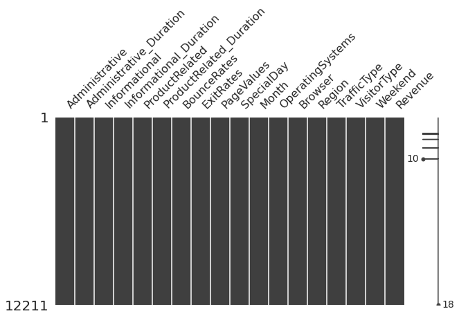

```python
msno.matrix(data,figsize=(10,5))   #Missinglerin nerde olduğu ve rastlantısallığına görsel şekilde bakalım.
```

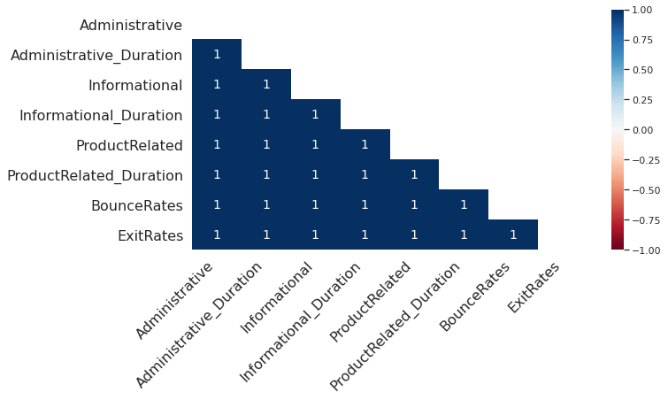

```python
msno.heatmap(data,figsize=(10,5))         #Missing Value'ların bir korelasyon içerisinde olduğunu gördük. Ayrıca bu tüm aynı satırların missing olduğu anlamına gelir.
                                          #Dropping bu yüzden iyi bir yöntem olabilir.
```

Eksik veriler az sayıda olduğundan, aynı gözlemlerin çoğu değişkeninde eksiklikler gözlendiğinden ve bu eksiklikler neticesinde bu gözlemlerin bilgi taşımamasından drop etmeyi uygun bulduk.

```python
data.dropna(inplace=True)
```

### Datamızda değerlerin sayısını görebilmek için value counts değerlerini bir sutun için çağırdık.

### Parametre olarak dropna=false vererek nan olan değerlerin de gözükmesini sağladık.

```python
data["Informational"].value_counts(dropna=False)
```

```
0.0     9569
1.0     1041
2.0      727
3.0      380
4.0      222
5.0       99
6.0       78
7.0       36
9.0       15
8.0       14
10.0       7
12.0       5
14.0       2
11.0       1
16.0       1
24.0       1
13.0       1
Name: Informational, dtype: int64
```

### Yapısal bir bozukluk olduğunu düşündüğümüzden bu aşamada data durationları -1 olan gözlemleri dropladık. (Süre negatif olamaz)

```python
data=data[(data["Administrative_Duration"]>=0)]

data.shape
```

```
(12166, 18)
```

```python
data_analysis=data_analysis.set_index("Variable")
```

```python
numerical_columns =  list(data_analysis[(data_analysis["Variables"] == 'Continuous') | (data_analysis["Variables"] == 'Cardinal')].index)
```

```python
categorical_columns = list(data_analysis.loc[(data_analysis.Variables=="Nominal") | (data_analysis.Variables=="Ordinal")].index)
len(categorical_columns), categorical_columns
```

```
(9,
 ['Region',
  'Weekend',
  'VisitorType',
  'TrafficType',
  'SpecialDay',
  'Browser',
  'OperatingSystems',
  'Month',
  'Revenue'])
```

### Target sütunu sayısal değere çeviriyoruz.

```python
from sklearn.preprocessing import LabelEncoder

le = LabelEncoder()
target = data.iloc[:,-1]
target = le.fit_transform(target)
target
```

```
array([0, 0, 0, ..., 0, 0, 0])
```

# Train - Test Split

```python
x_train,x_test,y_train,y_test=train_test_split(data.drop('Revenue', axis=1), target, test_size = 0.30, random_state=45)
```

# Değişkenlerin target (revenue) ile olan ilişkisi

```python
def plot_feature_distribution(df1, df2, label1, label2, features):
    i = 0
    sns.set_style('whitegrid')
    plt.figure()
    fig, ax = plt.subplots(3,3,figsize=(18,22))

    for feature in features:
        i += 1
        plt.subplot(3,3,i)
        sns.distplot(df1[feature], hist=False,label=label1)
        sns.distplot(df2[feature], hist=False,label=label2)
        plt.xlabel(feature, fontsize=9)### Eksik veriler sadece train
        locs, labels = plt.xticks()
        plt.tick_params(axis='x', which='major', labelsize=6, pad=-6)
        plt.tick_params(axis='y', which='major', labelsize=6)
    plt.show();
```

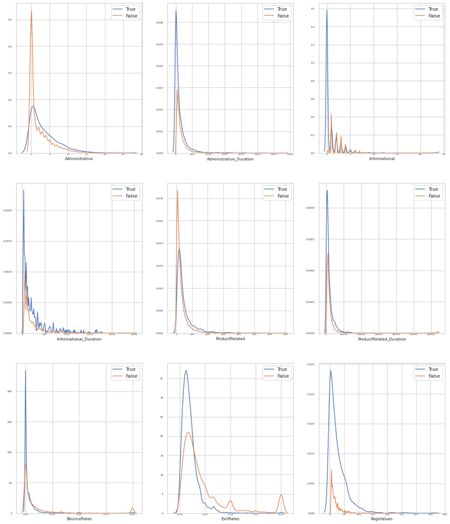

```python
t0 = data.loc[data['Revenue'] == True]
t1 = data.loc[data['Revenue'] == False]
features = data.columns.values[0:9]
plot_feature_distribution(t0, t1, 'True', 'False', features)
```

# Target dağılımının histogram olarak gösterimi

```python
%matplotlib inline
# Histogram of the target categories
def histogram(df,feature):
    #df = input("Enter a DataFrame name: ")
    #col = input("Enter a target column name: ")
    #df=eval(df)
    ncount = len(df)
    ax = sns.countplot(x = feature, data=df ,palette="hls")
    sns.set(font_scale=1)
    ax.set_xlabel('Target Segments')
    plt.xticks(rotation=90)
    ax.set_ylabel('Number of Observations')
    fig = plt.gcf()
    fig.set_size_inches(12,5)
    # Make twin axis
    ax2=ax.twinx()
    # Switch so count axis is on right, frequency on left
    ax2.yaxis.tick_left()
    ax.yaxis.tick_right()
    # Also switch the labels over
    ax.yaxis.set_label_position('right')
    ax2.yaxis.set_label_position('left')
    ax2.set_ylabel('Frequency [%]')
    for p in ax.patches:
        x=p.get_bbox().get_points()[:,0]
        y=p.get_bbox().get_points()[1,1]
        ax.annotate('{:.2f}%'.format(100.*y/ncount), (x.mean(), y),
                ha='center', va='bottom') # set the alignment of the text
    # Use a LinearLocator to ensure the correct number of ticks

    # Fix the frequency range to 0-100
    ax2.set_ylim(0,100)
    ax.set_ylim(0,ncount)
    # And use a MultipleLocator to ensure a tick spacing of 10

    # Need to turn the grid on ax2 off, otherwise the gridlines end up on top of the bars
    ax2.grid(None)
    plt.title('Histogram of Binary Target Categories', fontsize=20, y=1.08)
    plt.show()
    del ncount, x, y
```

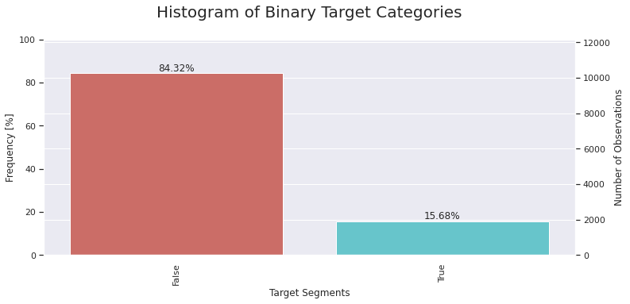

```python
histogram(data,"Revenue")
```

# Korelasyon Haritası

```python
data[numerical_columns].corr(method = 'spearman')
```

|  | Administrative | Informational | Informational_Duration | ProductRelated | ProductRelated_Duration | BounceRates | ExitRates | Administrative_Duration | PageValues |
| --- | --- | --- | --- | --- | --- | --- | --- | --- | --- |
| Administrative | 1.000000 | 0.366157 | 0.360025 | 0.450223 | 0.410382 | -0.137602 | -0.422963 | 0.938954 | 0.323895 |
| Informational | 0.366157 | 1.000000 | 0.950753 | 0.365171 | 0.363914 | 0.016942 | -0.178037 | 0.353912 | 0.216437 |
| Informational_Duration | 0.360025 | 0.950753 | 1.000000 | 0.357837 | 0.359530 | 0.007934 | -0.193294 | 0.349053 | 0.221088 |
| ProductRelated | 0.450223 | 0.365171 | 0.357837 | 1.000000 | 0.878131 | -0.016765 | -0.500031 | 0.419095 | 0.336740 |
| ProductRelated_Duration | 0.410382 | 0.363914 | 0.359530 | 0.878131 | 1.000000 | -0.044610 | -0.456108 | 0.402426 | 0.355479 |
| BounceRates | -0.137602 | 0.016942 | 0.007934 | -0.016765 | -0.044610 | 1.000000 | 0.588044 | -0.146412 | -0.115189 |
| ExitRates | -0.422963 | -0.178037 | -0.193294 | -0.500031 | -0.456108 | 0.588044 | 1.000000 | -0.426673 | -0.302531 |
| Administrative_Duration | 0.938954 | 0.353912 | 0.349053 | 0.419095 | 0.402426 | -0.146412 | -0.426673 | 1.000000 | 0.312767 |
| PageValues | 0.323895 | 0.216437 | 0.221088 | 0.336740 | 0.355479 | -0.115189 | -0.302531 | 0.312767 | 1.000000 |

```python
data
```

|  | Administrative | Administrative_Duration | Informational | Informational_Duration | ProductRelated | ProductRelated_Duration | BounceRates | ExitRates | PageValues | SpecialDay | Month | OperatingSystems | Browser | Region | TrafficType | VisitorType | Weekend | Revenue |
| --- | --- | --- | --- | --- | --- | --- | --- | --- | --- | --- | --- | --- | --- | --- | --- | --- | --- | --- |
| 0 | 0.0 | 0.0 | 0.0 | 0.0 | 1.0 | 0.000000 | 0.200000 | 0.200000 | 0.000000 | 0.0 | Feb | 1 | 1 | 1 | 1 | Returning_Visitor | False | False |
| 1 | 0.0 | 0.0 | 0.0 | 0.0 | 2.0 | 64.000000 | 0.000000 | 0.100000 | 0.000000 | 0.0 | Feb | 2 | 2 | 1 | 2 | Returning_Visitor | False | False |
| 3 | 0.0 | 0.0 | 0.0 | 0.0 | 2.0 | 2.666667 | 0.050000 | 0.140000 | 0.000000 | 0.0 | Feb | 3 | 2 | 2 | 4 | Returning_Visitor | False | False |
| 4 | 0.0 | 0.0 | 0.0 | 0.0 | 10.0 | 627.500000 | 0.020000 | 0.050000 | 0.000000 | 0.0 | Feb | 3 | 3 | 1 | 4 | Returning_Visitor | True | False |
| 5 | 0.0 | 0.0 | 0.0 | 0.0 | 19.0 | 154.216667 | 0.015789 | 0.024561 | 0.000000 | 0.0 | Feb | 2 | 2 | 1 | 3 | Returning_Visitor | False | False |
| ... | ... | ... | ... | ... | ... | ... | ... | ... | ... | ... | ... | ... | ... | ... | ... | ... | ... | ... |
| 12325 | 3.0 | 145.0 | 0.0 | 0.0 | 53.0 | 1783.791667 | 0.007143 | 0.029031 | 12.241717 | 0.0 | Dec | 4 | 6 | 1 | 1 | Returning_Visitor | True | False |
| 12326 | 0.0 | 0.0 | 0.0 | 0.0 | 5.0 | 465.750000 | 0.000000 | 0.021333 | 0.000000 | 0.0 | Nov | 3 | 2 | 1 | 8 | Returning_Visitor | True | False |
| 12327 | 0.0 | 0.0 | 0.0 | 0.0 | 6.0 | 184.250000 | 0.083333 | 0.086667 | 0.000000 | 0.0 | Nov | 3 | 2 | 1 | 13 | Returning_Visitor | True | False |
| 12328 | 4.0 | 75.0 | 0.0 | 0.0 | 15.0 | 346.000000 | 0.000000 | 0.021053 | 0.000000 | 0.0 | Nov | 2 | 2 | 3 | 11 | Returning_Visitor | False | False |
| 12329 | 0.0 | 0.0 | 0.0 | 0.0 | 3.0 | 21.250000 | 0.000000 | 0.066667 | 0.000000 | 0.0 | Nov | 3 | 2 | 1 | 2 | New_Visitor | True | False |

12166 rows × 18 columns

#### Pearson Korelasyonu aykırı verilere duyarlı olduğundan ve henüz aykırı verileri temizlemediğimizden dolayı "Spearman" korelasyonuna bakma gereği duyuyoruz.

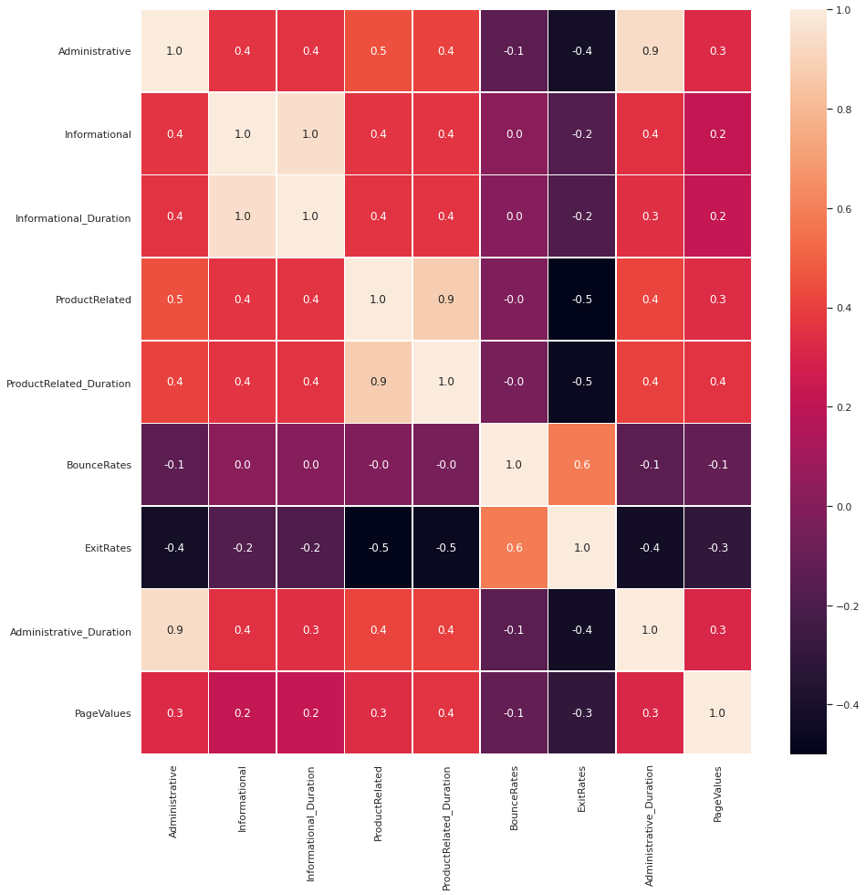

```python
f,ax = plt.subplots(figsize=(15,15))
sns.heatmap(data[numerical_columns].corr(method = 'spearman'), annot=True, linewidths=.5, fmt= '.1f',ax=ax)
plt.show()
```

# Kategorik Verilerin İncelenmesi

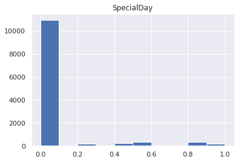

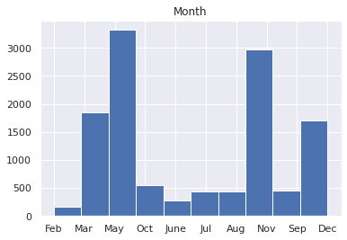

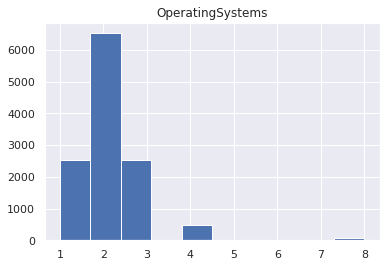

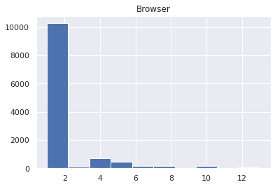

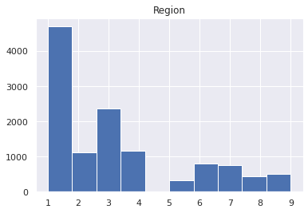

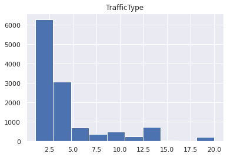

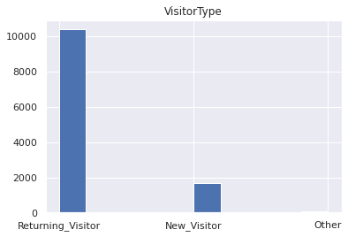

```python
plt.hist(data.loc[:,"SpecialDay"])
plt.title("SpecialDay")
plt.show()

plt.hist(data.loc[:,"Month"])
plt.title("Month")
plt.show()

plt.hist(data.loc[:,"OperatingSystems"])
plt.title("OperatingSystems")
plt.show()

plt.hist(data.loc[:,"Browser"])
plt.title("Browser")
plt.show()

plt.hist(data.loc[:,"Region"])
plt.title("Region")
plt.show()

plt.hist(data.loc[:,"TrafficType"])
plt.title("TrafficType")
plt.show()

plt.hist(data.loc[:,"VisitorType"])
plt.title("VisitorType")
plt.show()
```

# Sayısal Verilerin Yoğunluk Dağılımlı Görselleştirilmesi

```python
numerical_columns
```

```
['Administrative',
 'Informational',
 'Informational_Duration',
 'ProductRelated',
 'ProductRelated_Duration',
 'BounceRates',
 'ExitRates',
 'Administrative_Duration',
 'PageValues']
```

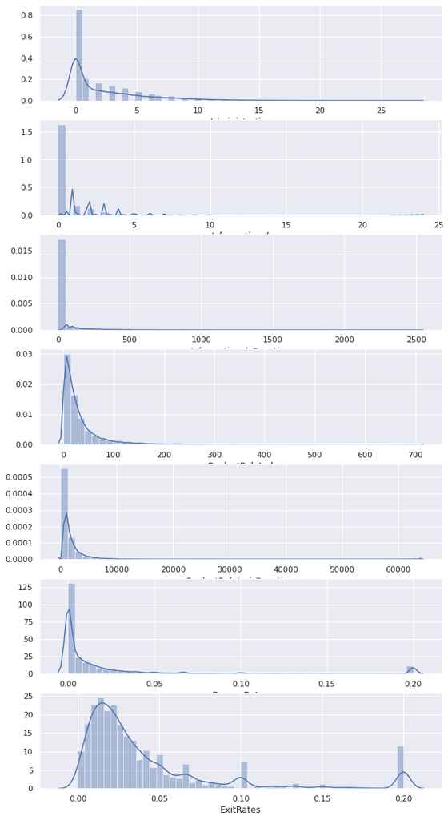

```python
#We plotted the numerical features

import matplotlib.pyplot as plt


f,axes=plt.subplots(7,1,figsize=(10,20))
sns.distplot(data[numerical_columns[0]],ax=axes[0])

sns.distplot(data[numerical_columns[1]],ax=axes[1])

sns.distplot(data[numerical_columns[2]],ax=axes[2])

sns.distplot(data[numerical_columns[3]],ax=axes[3])

sns.distplot(data[numerical_columns[4]],ax=axes[4])

sns.distplot(data[numerical_columns[5]],ax=axes[5])

sns.distplot(data[numerical_columns[6]],ax=axes[6])
```

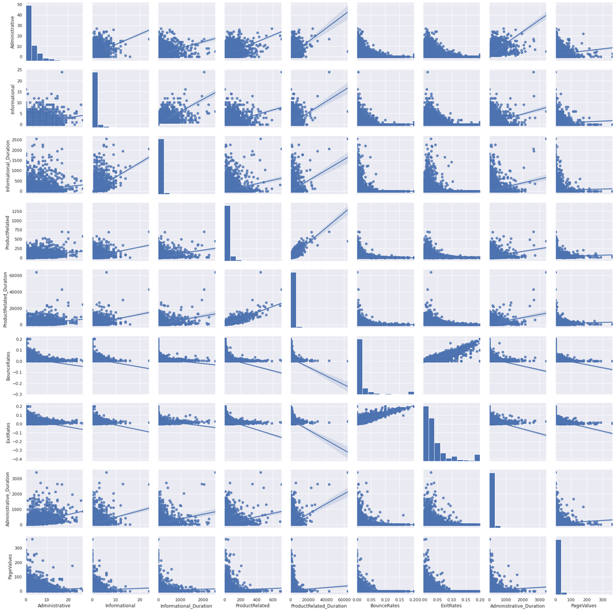

```python
sns.pairplot(data[numerical_columns],kind="reg")
```

# BI Variate Analysis

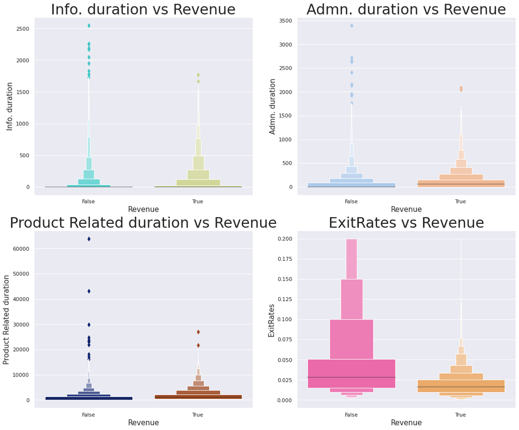

```python
plt.rcParams['figure.figsize'] = (18, 15)

plt.subplot(2, 2, 1)
sns.boxenplot(data['Revenue'], data['Informational_Duration'], palette = 'rainbow')
plt.title('Info. duration vs Revenue', fontsize = 30)
plt.xlabel('Revenue', fontsize = 15)
plt.ylabel('Info. duration', fontsize = 15)

# product related duration vs revenue

plt.subplot(2, 2, 2)
sns.boxenplot(data['Revenue'], data['Administrative_Duration'], palette = 'pastel')
plt.title('Admn. duration vs Revenue', fontsize = 30)
plt.xlabel('Revenue', fontsize = 15)
plt.ylabel('Admn. duration', fontsize = 15)

# product related duration vs revenue

plt.subplot(2, 2, 3)
sns.boxenplot(data['Revenue'], data['ProductRelated_Duration'], palette = 'dark')
plt.title('Product Related duration vs Revenue', fontsize = 30)
plt.xlabel('Revenue', fontsize = 15)
plt.ylabel('Product Related duration', fontsize = 15)

# exit rate vs revenue

plt.subplot(2, 2, 4)
sns.boxenplot(data['Revenue'], data['ExitRates'], palette = 'spring')
plt.title('ExitRates vs Revenue', fontsize = 30)
plt.xlabel('Revenue', fontsize = 15)
plt.ylabel('ExitRates', fontsize = 15)


plt.show()
```

# Skeewed Analizi

```python
df_train = x_train.copy()
numerical_columns_remains = numerical_columns

try:
    with open('left_skewed_columns.csv', 'r') as f:
        left_skewed_columns = list(csv.reader(f))[0][:-1]
except:
    if 'left_skewed_columns' not in globals():
        left_skewed_columns=[]
        for col in numerical_columns_remains:
            if df_train.loc[df_train[col]!=df_train[col].mode()[0],col].median() < -1:
                left_skewed_columns.append(col)

        with open('left_skewed_columns.csv','w') as f:
            for item in left_skewed_columns:
                f.write('%s,'%item)
    else:
        print("'left_skewed_columns' are already identified!")

epsilon=0.001

# Change the direction of skewness of 'left_skewed_columns':
for col in left_skewed_columns:
    if df_train[df_train[col]!=df_train[col].mode()[0]][col].median() < -1:
        df_train.loc[:,col] *= -1
    else:
        continue

sparse_columns=[]
for col in numerical_columns_remains:
    if (df_train[col].quantile(0.01)==df_train[col].quantile(0.25)==df_train[col].mode()[0]):
        sparse_columns.append(col)

sparse_columns_2=[]
for col in numerical_columns_remains:
    if (df_train[col].quantile(0.01)==df_train[col].quantile(0.25)):
        sparse_columns_2.append(col)


len(numerical_columns_remains), len(sparse_columns), len(sparse_columns_2)
```

```
(9, 6, 6)
```

# Outlier Tespiti

## Interquailtile yöntemi ile aykırı verileri inceleme

```python
Q1=data['Administrative_Duration'].quantile(0.25)
Q3=data['Administrative_Duration'].quantile(0.75)
IQR=Q3-Q1
minn=Q1-3*IQR
maxx=Q3+3*IQR
data['Administrative_Duration'][(data['Administrative_Duration']<minn) | (data['Administrative_Duration']> maxx)].count()
```

```
539
```

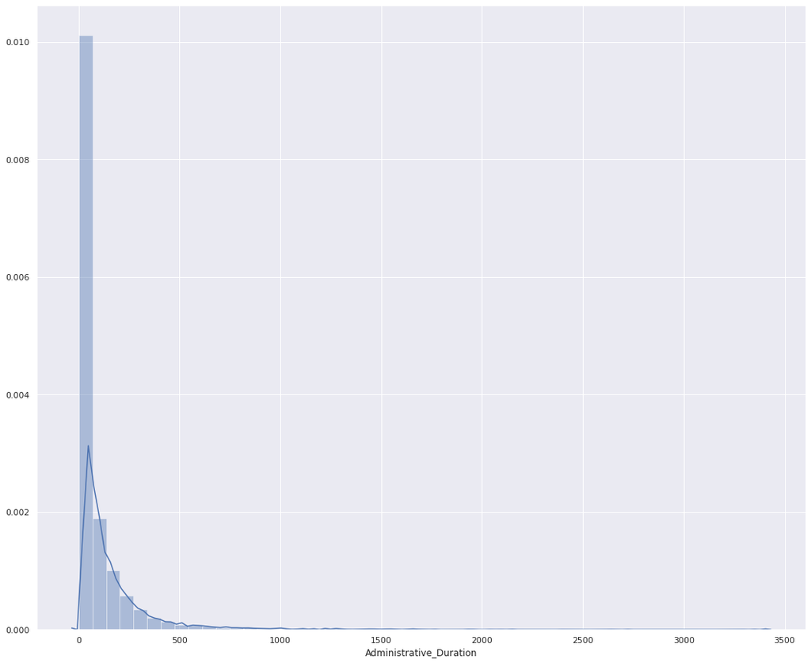

```python
sns.distplot(data.Administrative_Duration)
```

## Train datasında outlier tespiti

```python
"""
Algorithm 'HER' applies induction to the elements of a value line which are:

    - lower than the 1th quantile to that quantile and
    - upper than the 99th quantile to that quantile.

Main aim is to diminish negative effects of outlier values on analytical operations being performed.
"""

def HardEdgeReduction(df,numerical_columns,sparse_columns,upper_quantile=0.99,lower_quantile=0.01):

    import pandas as pd

    import psutil, os, gc, time
    print("HardEdgeReduction process has began:\n")
    proc = psutil.Process(os.getpid())
    gc.collect()
    mem_0 = proc.memory_info().rss
    start_time = time.time()

    # Do outlier cleaning in only one loop
    epsilon = 0.0001 # for zero divisions

    # Define boundaries that we will use for Reduction operation

    df_outlier_cleaned = df.copy()

    print("Detected outliers will be replaced with edged quantiles/percentiles: 1% and 99%!\n")
    print("Total number of rows is: %s\n"%df_outlier_cleaned.shape[0])

    outlier_boundries_dict={}

    for col in numerical_columns:

        if col in sparse_columns:

            # First ignore the 'sparse' data points:
            nonsparse_data = pd.DataFrame(df_outlier_cleaned[df_outlier_cleaned[col] !=\
                                                             df_outlier_cleaned[col].mode()[0]][col])

            #we used only mode to catch sparse points, since we know/proved it is enough to do that.

            # Find Outlier Thresholds:
            # Note: All columns are right-skewed
            # For lower threshold (left-hand-side)
            if nonsparse_data[col].quantile(lower_quantile) < df_outlier_cleaned[col].mode()[0]: #Unexpected case # Bu kısmı çözemezsek soralım
                lower_bound_sparse = nonsparse_data[col].quantile(lower_quantile)
            else:
                lower_bound_sparse = df_outlier_cleaned[col].mode()[0]

            # For upper threshold (right-hand-side)
            if nonsparse_data[col].quantile(upper_quantile) < df_outlier_cleaned[col].mode()[0]: #Unexpected case
                upper_bound_sparse = df_outlier_cleaned[col].mode()[0]
            else:
                upper_bound_sparse = nonsparse_data[col].quantile(upper_quantile)

            outlier_boundries_dict[col]=(lower_bound_sparse,upper_bound_sparse)

            # Inform user about the cardinality of Outlier existence:
            number_of_outliers = len(df_outlier_cleaned[(df_outlier_cleaned[col] < lower_bound_sparse) |\
                                                        (df_outlier_cleaned[col] > upper_bound_sparse)][col])
            print("Sparse: Outlier number in %s is equal to: "%col,number_of_outliers/(nonsparse_data.shape[0] -
                                                                                       nonsparse_data.isnull().sum()))

            # Replace Outliers with Edges --> 1% and 99%:
            if number_of_outliers > 0:

                # Replace 'left-hand-side' outliers with its 1% quantile value
                df_outlier_cleaned.loc[df_outlier_cleaned[col] < lower_bound_sparse,col] = lower_bound_sparse - epsilon # --> MAIN DF CHANGED

                # Replace 'right-hand-side' outliers with its 99% quantile value
                df_outlier_cleaned.loc[df_outlier_cleaned[col] > upper_bound_sparse,col] = upper_bound_sparse + epsilon # --> MAIN DF CHANGED

        else:
            # Find Edges:
            number_of_outliers = len(df_outlier_cleaned[(df_outlier_cleaned[col] < \
                                                         df_outlier_cleaned[col].quantile(lower_quantile))|\
                                                        (df_outlier_cleaned[col] > \
                                                         df_outlier_cleaned[col].quantile(upper_quantile))]\
                                     [col])
            print("Other: Outlier number in {} is equal to: ".format(col),number_of_outliers/(df[col].shape[0] -
                                                                                       df[col].isnull().sum()))

            # Replace 'Standard' outliers:
            if number_of_outliers > 0:
                # Replace all outliers with its %99 quartile
                lower_bound_sparse = df_outlier_cleaned[col].quantile(lower_quantile)
                df_outlier_cleaned.loc[df_outlier_cleaned[col] < \
                                       lower_bound_sparse,col] \
                = lower_bound_sparse  - epsilon

                upper_bound_sparse = df_outlier_cleaned[col].quantile(upper_quantile)
                df_outlier_cleaned.loc[df_outlier_cleaned[col] > \
                                       upper_bound_sparse,col] \
                = upper_bound_sparse  + epsilon

            outlier_boundries_dict[col]=(lower_bound_sparse,upper_bound_sparse)


    print('HardEdgeReduction process has been completed!')
    print("--- in %s minutes ---" % ((time.time() - start_time)/60))

    return df_outlier_cleaned, outlier_boundries_dict
```

```python
df_train_outlier_cleaned, outlier_boundries_dict = HardEdgeReduction(x_train, numerical_columns,sparse_columns)
```

```
HardEdgeReduction process has began:

Detected outliers will be replaced with edged quantiles/percentiles: 1% and 99%!

Total number of rows is: 8516

Sparse: Outlier number in Administrative is equal to:  Administrative    0.00673
dtype: float64
Sparse: Outlier number in Informational is equal to:  Informational    0.008082
dtype: float64
Sparse: Outlier number in Informational_Duration is equal to:  Informational_Duration    0.010035
dtype: float64
Other: Outlier number in ProductRelated is equal to:  0.012916862376702677
Other: Outlier number in ProductRelated_Duration is equal to:  0.010098637858149366
Sparse: Outlier number in BounceRates is equal to:  BounceRates    0.0
dtype: float64
Other: Outlier number in ExitRates is equal to:  0.009981211836542978
Sparse: Outlier number in Administrative_Duration is equal to:  Administrative_Duration    0.010209
dtype: float64
Sparse: Outlier number in PageValues is equal to:  PageValues    0.010074
dtype: float64
HardEdgeReduction process has been completed!
--- in 0.002310669422149658 minutes ---
```

```python
outlier_boundries_dict
```

```
{'Administrative': (0.0, 16.0),
 'Administrative_Duration': (0.0, 1144.5126470499972),
 'BounceRates': (0.0, 0.2),
 'ExitRates': (0.001282051, 0.2),
 'Informational': (0.0, 9.0),
 'Informational_Duration': (0.0, 1476.1424999999992),
 'PageValues': (0.0, 147.33959212500068),
 'ProductRelated': (1.0, 221.85000000000036),
 'ProductRelated_Duration': (0.0, 8758.861504550023)}
```

## Test datasında outlier tespiti

```python
# Do outlier cleaning in only one loop
epsilon = 0.0001 # for zero divisions

# Define boundaries that we will use for Reduction operation
upper_quantile = 0.99
lower_quantile = 0.01

df_test_outlier_cleaned = x_test.copy()

print("Detected outliers will be replaced with edged quantiles/percentiles: 1% and 99%!\n")
print("Total number of rows is: %s\n"%df_train_outlier_cleaned.shape[0])

for col in numerical_columns_remains:

      lower_bound = outlier_boundries_dict[col][0]
      upper_bound = outlier_boundries_dict[col][1]

      # Inform user about the cardinality of Outlier existence:
      number_of_outliers = len(df_test_outlier_cleaned[(df_test_outlier_cleaned[col] < lower_bound) |\
                                                        (df_test_outlier_cleaned[col] > upper_bound)][col])
      print("Sparse: Outlier number in %s is equal to: "%col, number_of_outliers/
            (df_test_outlier_cleaned[col].shape[0] - df_test_outlier_cleaned[col].isnull().sum()))

      # Replace Outliers with Edges --> 1% and 99%:
      if number_of_outliers > 0:

          # Replace 'left-hand-side' outliers with its 1% quantile value
          df_test_outlier_cleaned.loc[df_test_outlier_cleaned[col] < lower_bound,col] = lower_bound  - epsilon # --> MAIN DF CHANGED

          # Replace 'right-hand-side' outliers with its 99% quantile value
          df_test_outlier_cleaned.loc[df_test_outlier_cleaned[col] > upper_bound,col] = upper_bound  + epsilon # --> MAIN DF CHANGED
```

```
Detected outliers will be replaced with edged quantiles/percentiles: 1% and 99%!

Total number of rows is: 8516

Sparse: Outlier number in Administrative is equal to:  0.005479452054794521
Sparse: Outlier number in Informational is equal to:  0.0008219178082191781
Sparse: Outlier number in Informational_Duration is equal to:  0.0013698630136986301
Sparse: Outlier number in ProductRelated is equal to:  0.012876712328767123
Sparse: Outlier number in ProductRelated_Duration is equal to:  0.009863013698630137
Sparse: Outlier number in BounceRates is equal to:  0.0
Sparse: Outlier number in ExitRates is equal to:  0.011506849315068493
Sparse: Outlier number in Administrative_Duration is equal to:  0.005753424657534247
Sparse: Outlier number in PageValues is equal to:  0.002191780821917808
```

```python
x_test = df_test_outlier_cleaned
x_train = df_train_outlier_cleaned
```

# Kategorik verilerde encoding

# Train datasında encoding

```python
x_train1=x_train.copy()
x_test1=x_test.copy()

x_train1=pd.get_dummies(x_train1,columns=["Month"],prefix=["Month"],dummy_na=False)
x_test1=pd.get_dummies(x_test1,columns=["Month"],prefix=["Month"],dummy_na=False,)

binary_encoded_variables = ['TrafficType','Browser', 'OperatingSystems', 'Region', "VisitorType"]


binary_encoder = ce.BinaryEncoder(cols = binary_encoded_variables, drop_invariant=True)
binary_df = binary_encoder.fit_transform(x_train1[binary_encoded_variables])

le = LabelEncoder()
x_train["Weekend"] = le.fit_transform(x_train1["Weekend"])

x_train1.drop(binary_encoded_variables, axis=1, inplace=True)

frames = [x_train1, binary_df]
x_train1 = pd.concat(frames, axis=1)
```

## Test datasında encoding

```python
binary_df = binary_encoder.transform(x_test1[binary_encoded_variables])

x_test1["Weekend"] = le.transform(x_test1["Weekend"])

x_test1.drop(binary_encoded_variables, axis=1, inplace=True)

frames=[x_test1, binary_df]
x_test1 = pd.concat(frames, axis=1)

del binary_df
```

## x_train datasının yeni hali

```python
x_train1
```

|  | Administrative | Administrative_Duration | Informational | Informational_Duration | ProductRelated | ProductRelated_Duration | BounceRates | ExitRates | PageValues | SpecialDay | Weekend | Month_Aug | Month_Dec | Month_Feb | Month_Jul | Month_June | Month_Mar | Month_May | Month_Nov | Month_Oct | Month_Sep | TrafficType_1 | TrafficType_2 | TrafficType_3 | TrafficType_4 | TrafficType_5 | Browser_1 | Browser_2 | Browser_3 | … |
| --- | --- | --- | --- | --- | --- | --- | --- | --- | --- | --- | --- | --- | --- | --- | --- | --- | --- | --- | --- | --- | --- | --- | --- | --- | --- | --- | --- | --- | --- | --- |
| 523 | 1.0 | 3.000000 | 0.0 | 0.0 | 3.0 | 236.000000 | 0.000000 | 0.025000 | 0.000000 | 0.0 | True | 0 | 0 | 0 | 0 | 0 | 1 | 0 | 0 | 0 | 0 | 0 | 0 | 0 | 0 | 1 | 0 | 0 | 0 | … |
| 1115 | 0.0 | 0.000000 | 3.0 | 300.0 | 13.0 | 509.121429 | 0.006667 | 0.002222 | 40.793200 | 0.0 | True | 0 | 0 | 0 | 0 | 0 | 1 | 0 | 0 | 0 | 0 | 0 | 0 | 0 | 1 | 0 | 0 | 0 | 0 | … |
| 8112 | 0.0 | 0.000000 | 0.0 | 0.0 | 11.0 | 499.000000 | 0.000000 | 0.018182 | 0.000000 | 0.0 | False | 0 | 1 | 0 | 0 | 0 | 0 | 0 | 0 | 0 | 0 | 0 | 0 | 0 | 1 | 0 | 0 | 0 | 1 | … |
| 6056 | 0.0 | 0.000000 | 0.0 | 0.0 | 27.0 | 263.266667 | 0.000000 | 0.038519 | 0.000000 | 0.0 | False | 0 | 0 | 0 | 0 | 1 | 0 | 0 | 0 | 0 | 0 | 0 | 0 | 0 | 0 | 1 | 0 | 0 | 0 | … |
| 2889 | 1.0 | 37.000000 | 0.0 | 0.0 | 23.0 | 1817.000000 | 0.053333 | 0.073696 | 0.000000 | 0.0 | False | 0 | 0 | 0 | 0 | 0 | 0 | 1 | 0 | 0 | 0 | 0 | 0 | 0 | 1 | 1 | 0 | 0 | 0 | … |
| ... | ... | ... | ... | ... | ... | ... | ... | ... | ... | ... | ... | ... | ... | ... | ... | ... | ... | ... | ... | ... | ... | ... | ... | ... | ... | ... | ... | ... | ... | … |
| 175 | 3.0 | 87.000000 | 0.0 | 0.0 | 10.0 | 320.500000 | 0.000000 | 0.015385 | 0.000000 | 0.0 | False | 0 | 0 | 1 | 0 | 0 | 0 | 0 | 0 | 0 | 0 | 0 | 0 | 0 | 0 | 1 | 0 | 0 | 1 | … |
| 11969 | 0.0 | 0.000000 | 0.0 | 0.0 | 1.0 | 0.000000 | 0.200000 | 0.200000 | 0.000000 | 0.0 | False | 0 | 0 | 0 | 0 | 0 | 0 | 0 | 1 | 0 | 0 | 0 | 1 | 0 | 0 | 0 | 0 | 1 | 1 | … |
| 6133 | 7.0 | 54.842857 | 7.0 | 475.2 | 20.0 | 393.409524 | 0.027381 | 0.033929 | 0.000000 | 0.0 | False | 0 | 0 | 0 | 1 | 0 | 0 | 0 | 0 | 0 | 0 | 0 | 0 | 1 | 0 | 1 | 0 | 0 | 0 | … |
| 6680 | 3.0 | 16.000000 | 0.0 | 0.0 | 63.0 | 3908.754762 | 0.000000 | 0.001587 | 1.298232 | 0.0 | False | 1 | 0 | 0 | 0 | 0 | 0 | 0 | 0 | 0 | 0 | 0 | 0 | 1 | 0 | 1 | 0 | 0 | 1 | … |
| 7240 | 13.0 | 407.570000 | 0.0 | 0.0 | 146.0 | 2650.780526 | 0.000000 | 0.011184 | 0.000000 | 0.0 | True | 0 | 0 | 0 | 0 | 0 | 0 | 0 | 0 | 1 | 0 | 0 | 0 | 0 | 1 | 0 | 0 | 0 | 1 | … |

8516 rows × 40 columns

# Modellemeler

Modellemeler bölümünde; </br> 1- *XGBoost* modellenmesi-hiperparametre tuning-final modelinin kurulması </br> 2- *Random Forest* modellenmesi-hiperparametre tuning-final modelinin kurulması </br> 3- *LightGBM* modellenmesi-hiperparametre tuning-final modelinin kurulması </br> 4- *Logistic Regression* modellenmesi </br> 5- *Multi Layer Perceptron* modellenmesi hiperparametre tuning-final modelinin kurulması </br>

## XGBoost ile modelleme - accuracy score ve ROC score'un gözlemlenmesi

```
Accuracy_Score: 90.08%
```

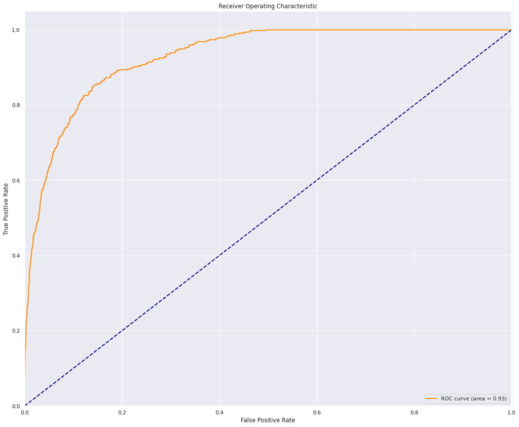

```python
from numpy import loadtxt
from xgboost import XGBClassifier
from sklearn.model_selection import train_test_split
from sklearn.metrics import accuracy_score, roc_auc_score, roc_curve, auc, roc_curve

model = XGBClassifier()
model.fit(x_train1, y_train)


y_pred = model.predict(x_test1)
predictions = [round(value) for value in y_pred]

accuracy_score_xbg = accuracy_score(y_test, predictions)
print("Accuracy_Score: %.2f%%" % (accuracy_score_xbg * 100.0))

xg_probs = model.predict_proba(x_test1)
xg_preds = xg_probs[:,1]
fpr, tpr, threshold = roc_curve(y_test, xg_preds)
roc_auc_xgb = auc(fpr, tpr)


lw = 2
plt.plot(fpr, tpr, color='darkorange',
         lw=lw, label='ROC curve (area = %0.2f)' % roc_auc_xgb)
plt.plot([0, 1], [0, 1], color='navy', lw=lw, linestyle='--')
plt.xlim([0.0, 1.0])
plt.ylim([0.0, 1.05])
plt.xlabel('False Positive Rate')
plt.ylabel('True Positive Rate')
plt.title('Receiver Operating Characteristic')
plt.legend(loc="lower right")
plt.show()
```

### XGBoost Feature Importance

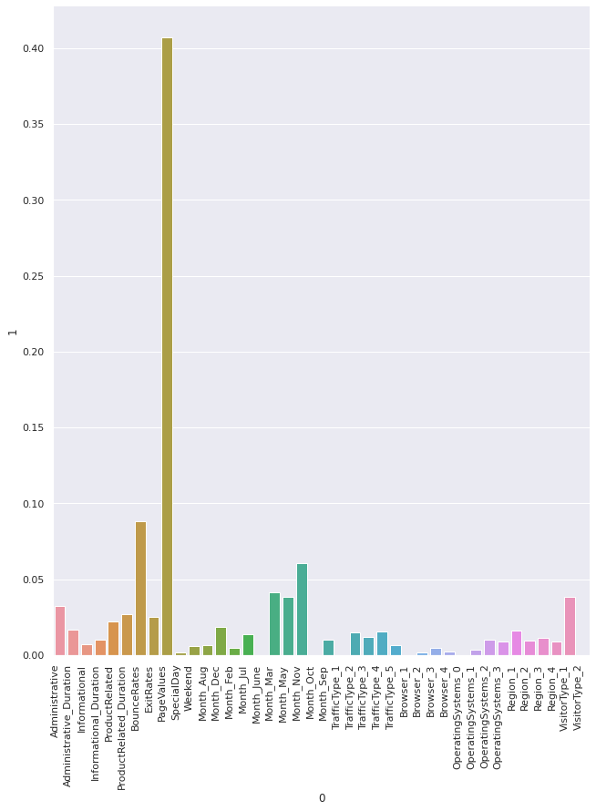

```python
feat_labels=x_train1.columns
importances=[]
df_feat=pd.DataFrame(model.feature_importances_)
df_feat
df_label=pd.DataFrame(feat_labels)
feat_labels
imp_data=pd.concat([df_label,df_feat],axis=1)
imp_data.columns=["0","1"]
imp_data
fig=plt.gcf()

g=sns.catplot(x="0",y="1",kind="bar",data=imp_data)
g.fig.set_figwidth(12)
g.fig.set_figheight(12)
g.set_xticklabels(rotation=90,horizontalalignment="right")
```

### PageValues ve Month sütunlarının taget ile ilişkisi

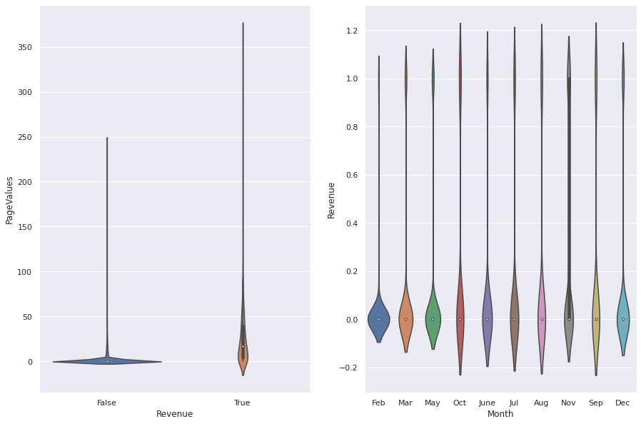

```python
a4_dims = (15,10)
fig, ax = plt.subplots(1,2,figsize=a4_dims)

sns.violinplot(x="Revenue", y="PageValues", data=data, ax=ax[0])

sns.violinplot(x="Month", y="Revenue", data=data, ax=ax[1])
```

## XGBoost model hiperparametrelerinin tune edilmesi

```python
xgb_params= {
    'n_estimators':[100,500,1000,2000],
    'subsample':[0.6,0.8,1.0],
    'max_depth':[3,4,5,6],
    'learning_rate':[0.1,0.01,0.02,0.05],
    'min_samples_split':[2,5,10]
}
```

```python
from sklearn.model_selection import GridSearchCV
xgb=XGBClassifier()
xgb_cv_model=GridSearchCV(xgb,
                          xgb_params,
                          cv=5,
                          n_jobs=-1,
                          verbose=2)
#xgb_cv_model.fit(x_train1,y_train)
```

```python
#xgb_cv_model.fit(x_train1,y_train)
```

```python
#xgb_cv_model.best_params_
```

```python
best_params_dict={'learning_rate': 0.01,
 'max_depth': 5,
 'min_samples_split': 2,
 'n_estimators': 500,
 'subsample': 0.6}
```

## XGBoost final modelinin/tune edilmiş modelin kurulması

```python
xgb_cv_model=XGBClassifier(learning_rate=0.01,
                           max_depth=5,
                           min_samples_split=2,
                           n_estimators=500,
                           subsample=0.6)
xgb_cv_model.fit(x_train1,y_train)
```

```
XGBClassifier(base_score=0.5, booster='gbtree', colsample_bylevel=1,
              colsample_bynode=1, colsample_bytree=1, gamma=0,
              learning_rate=0.01, max_delta_step=0, max_depth=5,
              min_child_weight=1, min_samples_split=2, missing=None,
              n_estimators=500, n_jobs=1, nthread=None,
              objective='binary:logistic', random_state=0, reg_alpha=0,
              reg_lambda=1, scale_pos_weight=1, seed=None, silent=None,
              subsample=0.6, verbosity=1)
```

## Final modelin kurulması

```
Accuracy: 90.27%
```

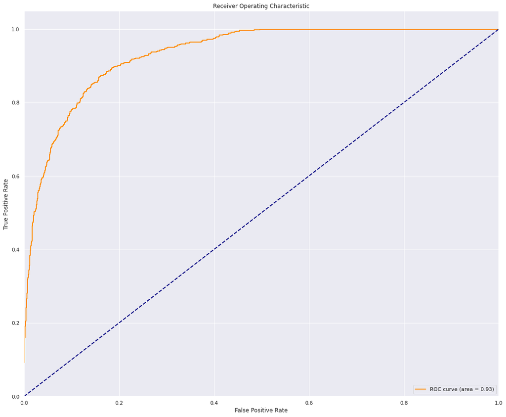

```python
y_cv_pred = xgb_cv_model.predict(x_test1)
predictions = [round(value) for value in y_cv_pred]

accuracy_score_tuned_xgb = accuracy_score(y_test, predictions)
print("Accuracy: %.2f%%" % (accuracy_score_tuned_xgb * 100.0))

xg_probs_tuned = xgb_cv_model.predict_proba(x_test1)
xg_preds_tuned = xg_probs_tuned[:,1]
fpr, tpr, threshold = roc_curve(y_test, xg_preds_tuned)
roc_auc_tuned_xgb = auc(fpr, tpr)

lw = 2
plt.plot(fpr, tpr, color='darkorange',
         lw=lw, label='ROC curve (area = %0.2f)' % roc_auc_tuned_xgb)
plt.plot([0, 1], [0, 1], color='navy', lw=lw, linestyle='--')
plt.xlim([0.0, 1.0])
plt.ylim([0.0, 1.05])
plt.xlabel('False Positive Rate')
plt.ylabel('True Positive Rate')
plt.title('Receiver Operating Characteristic')
plt.legend(loc="lower right")
plt.show()
```

## Random Forest modelinin kurulması

```
Training Accuracy : 1.0
Testing Accuracy : 0.8991780821917809
              precision    recall  f1-score   support

           0       0.92      0.96      0.94      3075
           1       0.73      0.57      0.64       575

    accuracy                           0.90      3650
   macro avg       0.83      0.76      0.79      3650
weighted avg       0.89      0.90      0.89      3650
```

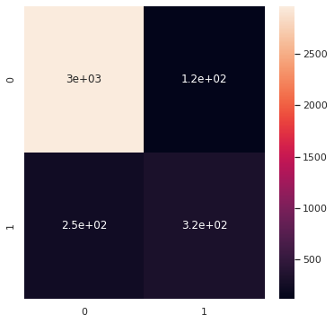

```python
from sklearn.ensemble import RandomForestClassifier
from sklearn.metrics import confusion_matrix
from sklearn.metrics import classification_report
from sklearn.metrics import roc_curve

model = RandomForestClassifier()
model.fit(x_train1, y_train)

y_pred3 = model.predict(x_test1)

# evaluating the model
print("Training Accuracy :", model.score(x_train1, y_train))
print("Testing Accuracy :", model.score(x_test1, y_test))
accuracy_score_rf=model.score(x_test1, y_test)


# confusion matrix
cm = confusion_matrix(y_test, y_pred3)
plt.rcParams['figure.figsize'] = (6, 6)
sns.heatmap(cm ,annot = True)

# classification report
cr = classification_report(y_test, y_pred3)
print(cr)
```

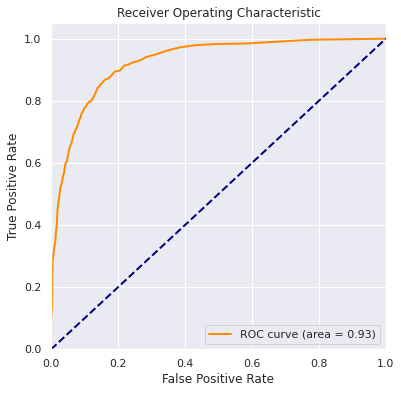

```python
rf_probs = model.predict_proba(x_test1)
rf_pred = rf_probs[:,1]
fpr, tpr, threshold = roc_curve(y_test, rf_pred)
roc_auc_rf = auc(fpr, tpr)



lw = 2
plt.plot(fpr, tpr, color='darkorange',
         lw=lw, label='ROC curve (area = %0.2f)' % roc_auc_rf)
plt.plot([0, 1], [0, 1], color='navy', lw=lw, linestyle='--')
plt.xlim([0.0, 1.0])
plt.ylim([0.0, 1.05])
plt.xlabel('False Positive Rate')
plt.ylabel('True Positive Rate')
plt.title('Receiver Operating Characteristic')
plt.legend(loc="lower right")
plt.show()
```

## Random Forest Classifier'ının tune edilmesi

```python
from sklearn.model_selection import GridSearchCV
rf_model2=RandomForestClassifier()
rf_params= {"max_depth": [2,5,8,10],
            "max_features": [2,5,8],
            "n_estimators":[10,500,1000],
            "min_samples_split":[2,5,10]}

rf_cv_model=GridSearchCV(rf_model2,
                         rf_params,
                         cv=10,
                         n_jobs=-1,
                         verbose=2)
```

```python
# rf_cv_model.fit(x_train1,y_train)
```

```python
# rf_cv_model.best_params_
```

```python
#rf_tuned=RandomForestClassifier(max_depth=8,
#                                max_features=5,
#                                min_samples_split=5,
#                                n_estimators=500)
```

## Random Forest Classifier final modelinin/tune edilmiş modelinin kurulması

```
Training Accuracy : 0.9491545326444341
Testing Accuracy : 0.9032876712328767
              precision    recall  f1-score   support

           0       0.93      0.96      0.94      3075
           1       0.75      0.58      0.66       575

    accuracy                           0.90      3650
   macro avg       0.84      0.77      0.80      3650
weighted avg       0.90      0.90      0.90      3650
```

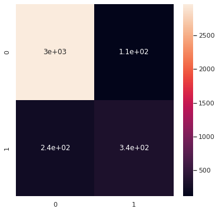

```python
rf_tuned=RandomForestClassifier(max_depth=10,
                                max_features=8,
                                min_samples_split=5,
                                n_estimators=1000)
rf_tuned.fit(x_train1,y_train)
y_pred4=rf_tuned.predict(x_test1)
accuracy_score_tuned_rf=accuracy_score(y_test,y_pred4)


# evaluating the model
print("Training Accuracy :", rf_tuned.score(x_train1, y_train))
print("Testing Accuracy :", rf_tuned.score(x_test1, y_test))


# confusion matrix
cm = confusion_matrix(y_test, y_pred4)
plt.rcParams['figure.figsize'] = (6, 6)
sns.heatmap(cm ,annot = True)

# classification report
cr = classification_report(y_test, y_pred4)
print(cr)
```

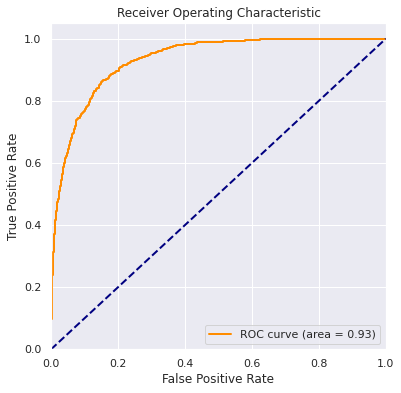

```python
rf_probs_tuned = rf_tuned.predict_proba(x_test1)
rf_pred_tuned = rf_probs_tuned[:,1]
fpr, tpr, threshold = roc_curve(y_test, rf_pred_tuned)
roc_auc_tuned_rf = auc(fpr, tpr)



lw = 2
plt.plot(fpr, tpr, color='darkorange',
         lw=lw, label='ROC curve (area = %0.2f)' % roc_auc_tuned_rf)
plt.plot([0, 1], [0, 1], color='navy', lw=lw, linestyle='--')
plt.xlim([0.0, 1.0])
plt.ylim([0.0, 1.05])
plt.xlabel('False Positive Rate')
plt.ylabel('True Positive Rate')
plt.title('Receiver Operating Characteristic')
plt.legend(loc="lower right")
plt.show()
```

## LightGBM Classifier modelinin kurulması ve accuracy score'un gözlenmesi

```
Accuracy Score :  0.8972602739726028
```

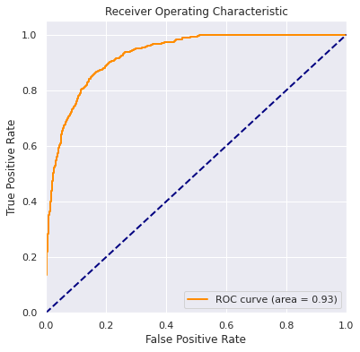

```python
from lightgbm import LGBMClassifier
lgbm_model=LGBMClassifier()
lgbm_model.fit(x_train1,y_train)

y_pred_lgbm=lgbm_model.predict(x_test1)
accuracy_score_lgbm=accuracy_score(y_test,y_pred_lgbm)
print("Accuracy Score : ",accuracy_score_lgbm)

lgbm_prob = lgbm_model.predict_proba(x_test1)
lgbm_pred = lgbm_prob[:,1]
fpr, tpr, threshold = roc_curve(y_test, lgbm_pred)
roc_auc_lgbm = auc(fpr, tpr)


lw = 2
plt.plot(fpr, tpr, color='darkorange',
         lw=lw, label='ROC curve (area = %0.2f)' % roc_auc_lgbm)
plt.plot([0, 1], [0, 1], color='navy', lw=lw, linestyle='--')
plt.xlim([0.0, 1.0])
plt.ylim([0.0, 1.05])
plt.xlabel('False Positive Rate')
plt.ylabel('True Positive Rate')
plt.title('Receiver Operating Characteristic')
plt.legend(loc="lower right")
plt.show()
```

```python
lgbm_params={"n_estimators":[100,500,1000,2000],
             "subsample":[0.6,0.8,1.0],
             "max_depth":[3,4,5,6],
             "learning_rate":[0.1,0.01,0.02,0.05],
             "min_child_samples":[5,10,20]}
```

## LGBM Tune Edilmesi

```python
lgbm_cv_model=GridSearchCV(lgbm_model,
                           lgbm_params,
                           cv=10,
                           n_jobs=-1,
                           verbose=2)
```

```python
#lgbm_cv_model.fit(x_train1,y_train)
```

```python
#lgbm_cv_model.best_params_
```

## Tune Edilmiş LGMB Modelinin Kurulması

```python
lgbm_tuned=LGBMClassifier(learning_rate=0.01,
                          max_depth=4,
                          min_child_samples=10,
                          n_estimators=1000,
                          subsample=0.6)
lgbm_tuned.fit(x_train1,y_train)
```

```
LGBMClassifier(boosting_type='gbdt', class_weight=None, colsample_bytree=1.0,
               importance_type='split', learning_rate=0.01, max_depth=4,
               min_child_samples=10, min_child_weight=0.001, min_split_gain=0.0,
               n_estimators=1000, n_jobs=-1, num_leaves=31, objective=None,
               random_state=None, reg_alpha=0.0, reg_lambda=0.0, silent=True,
               subsample=0.6, subsample_for_bin=200000, subsample_freq=0)
```

```
Accuracy_Score:  0.9002739726027398
```

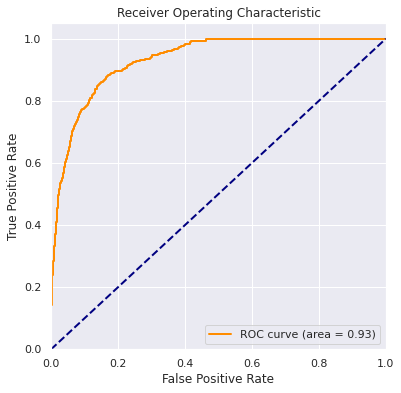

```python
y_pred_lgbm=lgbm_tuned.predict(x_test1)

accuracy_score_tuned_lgbm=accuracy_score(y_test,y_pred_lgbm)
print("Accuracy_Score: ",accuracy_score_tuned_lgbm)

lgbm_prob_tuned = lgbm_tuned.predict_proba(x_test1)
lgbm_pred_tuned = lgbm_prob_tuned[:,1]
fpr, tpr, threshold = roc_curve(y_test, lgbm_pred_tuned)
roc_auc_tuned_lgbm = auc(fpr, tpr)


lw = 2
plt.plot(fpr, tpr, color='darkorange',
         lw=lw, label='ROC curve (area = %0.2f)' % roc_auc_tuned_lgbm)
plt.plot([0, 1], [0, 1], color='navy', lw=lw, linestyle='--')
plt.xlim([0.0, 1.0])
plt.ylim([0.0, 1.05])
plt.xlabel('False Positive Rate')
plt.ylabel('True Positive Rate')
plt.title('Receiver Operating Characteristic')
plt.legend(loc="lower right")
plt.show()
```

## Logistic Regression Modelinin Kurulması

```
Test Accuracy of LR Algorithm: 87.97%
```

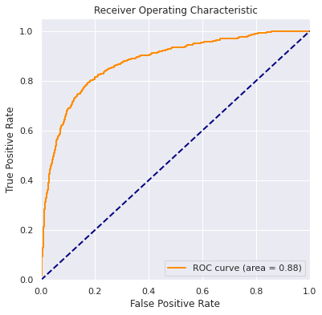

```python
lr = LogisticRegression()
lr
lr.fit(x_train1,y_train)
lr_score = lr.score(x_test1,y_test)
print("Test Accuracy of LR Algorithm: {:.2f}%".format(lr_score*100))
y_pred5 = lr.predict(x_test1)

lr_prob = lr.predict_proba(x_test1)
lr_pred = lr_prob[:,1]
fpr, tpr, threshold = roc_curve(y_test, lr_pred)
roc_auc = auc(fpr, tpr)


lw = 2
plt.plot(fpr, tpr, color='darkorange',
         lw=lw, label='ROC curve (area = %0.2f)' % roc_auc)
plt.plot([0, 1], [0, 1], color='navy', lw=lw, linestyle='--')
plt.xlim([0.0, 1.0])
plt.ylim([0.0, 1.05])
plt.xlabel('False Positive Rate')
plt.ylabel('True Positive Rate')
plt.title('Receiver Operating Characteristic')
plt.legend(loc="lower right")
plt.show()
```

## MLP Classifier Modelinin Kurulması

```
MLP Score: 79.64%
```

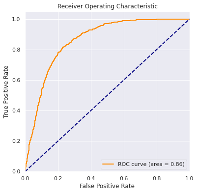

```python
from sklearn.neural_network import MLPClassifier
mlp_model=MLPClassifier()
mlp_model.fit(x_train1,y_train)
y_mlp_pred=mlp_model.predict(x_test1)

mlp_score=mlp_model.score(x_test1,y_test)
print("MLP Score: {:.2f}%".format(mlp_score*100))

mlp_prob = mlp_model.predict_proba(x_test1)
mlp_pred = mlp_prob[:,1]
fpr, tpr, threshold = roc_curve(y_test, mlp_pred)
roc_auc_mlp = auc(fpr, tpr)


lw = 2
plt.plot(fpr, tpr, color='darkorange',
         lw=lw, label='ROC curve (area = %0.2f)' % roc_auc_mlp)
plt.plot([0, 1], [0, 1], color='navy', lw=lw, linestyle='--')
plt.xlim([0.0, 1.0])
plt.ylim([0.0, 1.05])
plt.xlabel('False Positive Rate')
plt.ylabel('True Positive Rate')
plt.title('Receiver Operating Characteristic')
plt.legend(loc="lower right")
plt.show()
```

## MLP Classifier Modelinin Tune Edilmesi

```python
 """mlp_params={"alpha":[0.1,0.01,0.02,0.005,0.0001,0.00001],
             "hidden_layer_sizes":[(30,30,30),(100,100,100),(100,100),
                                   (200,150,140),(250,180,160)],
             "solver":["adam","sgd"],
             "activation":["relu","logistic"]}"""
 mlp_params={"alpha":[0.1,0.01,0.02,0.005,0.0001,0.00001],
             "hidden_layer_sizes":[(40,40,40),(45,45,45),(50,50,50),(50,40,40)],
             "solver":["adam"],
             "activation":["logistic"]}
```

```python
#mlp_cv_model=GridSearchCV(mlp_model,mlp_params,cv=10,n_jobs=-1,verbose=2)
#mlp_cv_model.fit(x_train1,y_train)
```

```python
#print("En iyi parametreler: "+str(mlp_cv_model.best_params_))
```

## MLP Classifier Final Modelinin/Tune Edilmiş Modelinin Kurulması

```
MLP Score: 88.05%
```

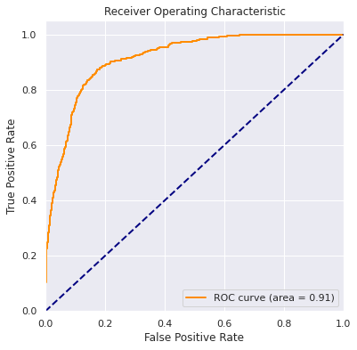

```python
mlp_tuned=MLPClassifier(activation="logistic",alpha=0.02,
                       hidden_layer_sizes=(50,40,40),
                       solver="adam")
mlp_tuned.fit(x_train1,y_train)
y_mlp_tuned=mlp_tuned.predict(x_test1)

mlp_cv_score=mlp_tuned.score(x_test1,y_test)
print("MLP Score: {:.2f}%".format(mlp_cv_score*100))

mlp_prob_tuned = mlp_tuned.predict_proba(x_test1)
mlp_pred_tuned = mlp_prob_tuned[:,1]
fpr, tpr, threshold = roc_curve(y_test, mlp_pred_tuned)
roc_auc_tuned_mlp = auc(fpr, tpr)

lw = 2
plt.plot(fpr, tpr, color='darkorange',
         lw=lw, label='ROC curve (area = %0.2f)' % roc_auc_tuned_mlp)
plt.plot([0, 1], [0, 1], color='navy', lw=lw, linestyle='--')
plt.xlim([0.0, 1.0])
plt.ylim([0.0, 1.05])
plt.xlabel('False Positive Rate')
plt.ylabel('True Positive Rate')
plt.title('Receiver Operating Characteristic')
plt.legend(loc="lower right")
plt.show()
```

# Modellerin Karşılaştırılması

```python
modelss={"XGB":[round(roc_auc_xgb*100,2),round(roc_auc_tuned_xgb*100,2),round(accuracy_score_xbg*100,2),
                round(accuracy_score_tuned_xgb*100,2)],
         "Random Forest":[round(roc_auc_rf*100,2),round(roc_auc_tuned_rf*100,2),
                          round(accuracy_score_rf*100,2),round(accuracy_score_tuned_rf*100,2)],
         "LGBM":[round(roc_auc_lgbm*100,2),round(roc_auc_tuned_lgbm*100,2),
                 round(accuracy_score_lgbm*100,2),round(accuracy_score_tuned_lgbm*100,2)],
         "MLPClassifier":[round(roc_auc_mlp*100,2),round(roc_auc_tuned_mlp*100,2),
                          round(mlp_score*100,2),round(mlp_cv_score*100,2)],
         "Logistic Regression":[round(roc_auc*100,2),round(roc_auc*100,2),round(lr_score*100,2),round(lr_score*100,2)]}
index=["Roc_Score","Tuned_Roc_Score","Accuracy_Score","Tuned_Accuracy_Score"]
df_modelss=pd.DataFrame(modelss)
df_modelss.index=index
df_modelss
```

|  | XGB | Random Forest | LGBM | MLPClassifier | Logistic Regression |
| --- | --- | --- | --- | --- | --- |
| Roc_Score | 93.02 | 92.57 | 92.80 | 85.89 | 87.63 |
| Tuned_Roc_Score | 93.28 | 93.18 | 93.17 | 91.44 | 87.63 |
| Accuracy_Score | 90.08 | 89.92 | 89.73 | 79.64 | 87.97 |
| Tuned_Accuracy_Score | 90.27 | 90.33 | 90.03 | 88.05 | 87.97 |

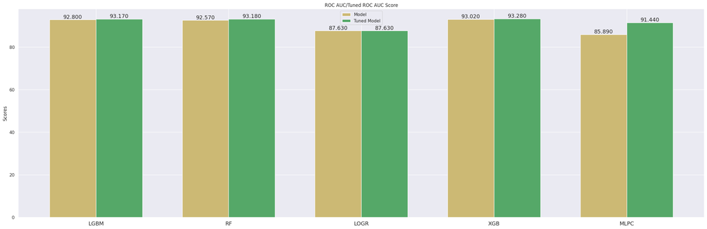

```python
aoc_scores_dict={}
N = 5
aoc_scores_dict["LGBM"]=(round(roc_auc_lgbm*100,2),round(roc_auc_tuned_lgbm*100,2))
aoc_scores_dict["RF"]=(round(roc_auc_rf*100,2),round(roc_auc_tuned_rf*100,2))
aoc_scores_dict["LOGR"]=(round(roc_auc*100,2),round(roc_auc*100,2))
aoc_scores_dict["XGB"]=(round(roc_auc_xgb*100,2),round(roc_auc_tuned_xgb*100,2))
aoc_scores_dict["MLPC"]=(round(roc_auc_mlp*100,2),round(roc_auc_tuned_mlp*100,2))

bars1=[aoc_scores_dict["LGBM"][0],aoc_scores_dict["RF"][0],aoc_scores_dict["LOGR"][0],aoc_scores_dict["XGB"][0],aoc_scores_dict["MLPC"][0]]
bars2 =[aoc_scores_dict["LGBM"][1],aoc_scores_dict["RF"][1],aoc_scores_dict["LOGR"][1],aoc_scores_dict["XGB"][1],aoc_scores_dict["MLPC"][1]]

ind = np.arange(N)  # the x locations for the groups
width = 0.35      # the width of the bars


fig, ax = plt.subplots(figsize=(32, 10),dpi=100)
rects1 = ax.bar(ind, bars1, width, color='y')

rects2 = ax.bar(ind + width, bars2, width, color='g')

ax.set_ylabel('Scores')
ax.set_title('ROC AUC/Tuned ROC AUC Score')
ax.set_xticks(ind + width / 2)
ax.set_xticklabels(('LGBM', 'RF', 'LOGR',"XGB", "MLPC"),fontsize=14)

ax.legend((rects1[0], rects2[0]), ('Model', "Tuned Model"))


def autolabel(rects):
    """
    Attach a text label above each bar displaying its height
    """
    for rect in rects:
        height = rect.get_height()
        ax.text(rect.get_x() + rect.get_width()/2., 1*height,
                '%.3f' % height,fontsize=14,
                ha='center', va='bottom')

autolabel(rects1)
autolabel(rects2)
```